# MPDW

2026-09-03

## Pendahuluan

Laporan ini menganalisis Indeks Pembangunan Manusia (IPM) Provinsi Sulawesi Tengah periode 2010–2021 menggunakan model regresi linear sederhana, dengan **Tahun** sebagai variabel bebas (X) dan **IPM** sebagai variabel terikat (Y). Setelah model awal dibentuk, dilakukan pengecekan autokorelasi pada residual menggunakan uji Durbin-Watson. Jika ditemukan autokorelasi, ditangani dengan dua metode: **Cochrane-Orcutt** dan **Hildreth-Lu**.

## 1. Memuat Package

Package `dplyr` digunakan untuk manipulasi data, sedangkan `lmtest` menyediakan fungsi `dwtest()` yang menjadi alat utama untuk mendeteksi autokorelasi pada bagian selanjutnya.

```r
library(dplyr)
library(lmtest)
```

## 2. Input Data

Data IPM Sulawesi Tengah tahun 2010–2021 dimasukkan secara manual berdasarkan data resmi BPS. Variabel `Provinsi` diulang 12 kali (`rep()`) agar sejajar dengan 12 baris tahun, dan `knitr::kable()` menampilkan data dalam bentuk tabel yang rapi pada laporan.

```r
data_prov <- data.frame(
  Provinsi = rep("SULAWESI TENGAH", 12),
  Tahun = 2010:2021,
  IPM = c(63.29, 64.27, 65.00, 65.79, 66.43, 66.76,
          67.47, 68.11, 68.88, 69.50, 69.55, 69.79)
)
knitr::kable(data_prov, caption = "Data IPM Sulawesi Tengah 2010-2021")
```

Data IPM Sulawesi Tengah 2010-2021

| Provinsi | Tahun | IPM |
| --- | --- | --- |
| SULAWESI TENGAH | 2010 | 63.29 |
| SULAWESI TENGAH | 2011 | 64.27 |
| SULAWESI TENGAH | 2012 | 65.00 |
| SULAWESI TENGAH | 2013 | 65.79 |
| SULAWESI TENGAH | 2014 | 66.43 |
| SULAWESI TENGAH | 2015 | 66.76 |
| SULAWESI TENGAH | 2016 | 67.47 |
| SULAWESI TENGAH | 2017 | 68.11 |
| SULAWESI TENGAH | 2018 | 68.88 |
| SULAWESI TENGAH | 2019 | 69.50 |
| SULAWESI TENGAH | 2020 | 69.55 |
| SULAWESI TENGAH | 2021 | 69.79 |

## 3. Statistik Deskriptif

Sebelum masuk ke pemodelan, dihitung ringkasan statistik dasar: nilai IPM minimum (2010), maksimum (2021), rata-rata, standar deviasi, serta total kenaikan IPM dari tahun awal ke tahun akhir (`data_prov$IPM[12] - data_prov$IPM[1]`). Hasilnya menunjukkan IPM naik konsisten sebesar 6.50 poin selama 12 tahun, dengan rata-rata 67.07 dan sebaran (SD) yang relatif kecil (2.19) - mengindikasikan tren yang stabil dan hampir linear.

```r
summary_df <- data.frame(
  Ukuran = c("Minimum", "Maksimum", "Rata-rata (Mean)", "Standar Deviasi", "Kenaikan (2010-2021)"),
  Nilai  = round(c(min(data_prov$IPM), max(data_prov$IPM), mean(data_prov$IPM), sd(data_prov$IPM),
                   data_prov$IPM[12] - data_prov$IPM[1]), 2)
)
knitr::kable(summary_df, caption = "Statistik Deskriptif IPM Sulawesi Tengah")
```

Statistik Deskriptif IPM Sulawesi Tengah

| Ukuran | Nilai |
| --- | --- |
| Minimum | 63.29 |
| Maksimum | 69.79 |
| Rata-rata (Mean) | 67.07 |
| Standar Deviasi | 2.19 |
| Kenaikan (2010-2021) | 6.50 |

## 4. Plot Tren IPM

Grafik berikut memvisualisasikan perkembangan IPM dari tahun ke tahun (`type = "b"` menampilkan titik dan garis sekaligus). Tujuannya untuk melihat secara visual apakah pola datanya mendekati garis lurus sebelum benar-benar dimodelkan dengan regresi linear.

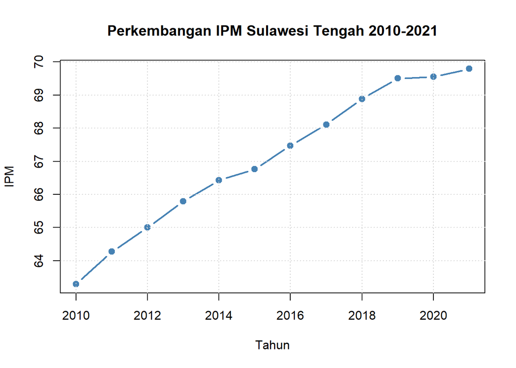

```r
plot(data_prov$Tahun, data_prov$IPM,
     main = "Perkembangan IPM Sulawesi Tengah 2010-2021",
     xlab = "Tahun", ylab = "IPM",
     pch = 19, col = "steelblue", type = "b", lwd = 2)
grid()
```

## 5. Model Regresi Linear (OLS)

Model regresi linear sederhana dibentuk dengan `lm(IPM ~ Tahun)`, dibaca sebagai “IPM dijelaskan oleh Tahun”. Fungsi `summary()` menampilkan estimasi koefisien, standard error, uji signifikansi (uji-t), serta nilai R².

**Hasil:** Intercept = -1143.08, Slope (Tahun) = 0.6004, keduanya sangat signifikan (p < 0.001). R² = 0.9814, artinya 98.14% variasi IPM dapat dijelaskan secara linear oleh waktu. Setiap bertambah 1 tahun, IPM diprediksi naik rata-rata 0.6004 poin.

```r
model_ols <- lm(IPM ~ Tahun, data = data_prov)
summary(model_ols)
```

```
##
## Call:
## lm(formula = IPM ~ Tahun, data = data_prov)
##
## Residuals:
##      Min       1Q   Median       3Q      Max
## -0.58231 -0.12906  0.06563  0.23094  0.32853
##
## Coefficients:
##               Estimate Std. Error t value Pr(>|t|)
## (Intercept) -1.143e+03  5.268e+01  -21.70 9.65e-10 ***
## Tahun        6.004e-01  2.614e-02   22.97 5.51e-10 ***
## ---
## Signif. codes:  0 '***' 0.001 '**' 0.01 '*' 0.05 '.' 0.1 ' ' 1
##
## Residual standard error: 0.3125 on 10 degrees of freedom
## Multiple R-squared:  0.9814, Adjusted R-squared:  0.9795
## F-statistic: 527.8 on 1 and 10 DF,  p-value: 5.514e-10
```

## 6. Scatter Plot dengan Garis Regresi

Titik-titik data digambar ulang, lalu `abline(model_ols, ...)` menambahkan garis regresi OLS di atasnya. Ini menjadi bukti visual bahwa model garis lurus memang cocok mengikuti pola data, mendukung nilai R² yang tinggi pada tahap sebelumnya.

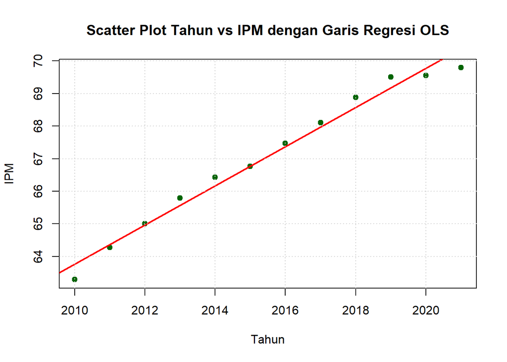

```r
plot(data_prov$Tahun, data_prov$IPM,
     main = "Scatter Plot Tahun vs IPM dengan Garis Regresi OLS",
     xlab = "Tahun", ylab = "IPM",
     pch = 19, col = "darkgreen")
abline(model_ols, col = "red", lwd = 2)
grid()
```

## 7. Uji Autokorelasi: Durbin-Watson

Model yang sangat fit pada data time series justru rawan menyembunyikan autokorelasi pada residualnya, sehingga perlu diuji dengan `dwtest()`. Statistik Durbin-Watson (DW) berkisar 0-4: nilai mendekati 2 menandakan tidak ada autokorelasi, mendekati 0 menandakan autokorelasi positif kuat. Uji ini menggunakan H0: tidak ada autokorelasi, H1: ada autokorelasi positif.

**Hasil:** DW = 0.76485, p-value = 0.001325. Karena DW jauh di bawah 2 dan p-value < 0.05, **H0 ditolak** - residual model OLS mengandung autokorelasi positif. Ini berarti standard error pada model OLS tidak lagi akurat, sehingga perlu ditangani sebelum model dipakai untuk inferensi lebih lanjut.

```r
dw_awal <- dwtest(model_ols)
dw_awal
```

```
##
##  Durbin-Watson test
##
## data:  model_ols
## DW = 0.76485, p-value = 0.001325
## alternative hypothesis: true autocorrelation is greater than 0
```

## 8. Penanganan 1: Metode Cochrane-Orcutt

Cochrane-Orcutt menangani autokorelasi dengan mengestimasi koefisien autokorelasi ρ (rho) secara **iteratif** dari residual, lalu mentransformasi data (*quasi-differencing*): `Yt − ρ·Yt-1` dan `Xt − ρ·Xt-1`. Proses ini diulang sampai nilai ρ konvergen (perubahannya lebih kecil dari `tol`) atau mencapai `max_iter` iterasi.

Rincian fungsi:

- `rho <- 0` - nilai awal ρ diasumsikan nol (belum ada autokorelasi).
- Di setiap iterasi, data ditransformasi dengan ρ saat ini, lalu diregresi ulang (`lm(y_t ~ x_t)`).
- `rho_new` dihitung dari korelasi lag-1 pada residual model transformasi tersebut.
- Jika perubahan ρ sudah sangat kecil, loop berhenti (`break`); jika belum, ρ diperbarui dan iterasi berlanjut.

```r
cochrane_orcutt_manual <- function(model, max_iter = 50, tol = 1e-6) {
  x <- model.matrix(model)[, -1]
  y <- model.response(model.frame(model))
  n <- length(y)
  rho <- 0
  for (i in 1:max_iter) {
    y_t <- y[2:n] - rho * y[1:(n - 1)]
    x_t <- x[2:n] - rho * x[1:(n - 1)]
    m   <- lm(y_t ~ x_t)
    e   <- residuals(m)
    rho_new <- sum(e[-1] * e[-length(e)]) / sum(e[-length(e)]^2)
    if (abs(rho_new - rho) < tol) {
      rho <- rho_new
      break
    }
    rho <- rho_new
  }
  y_t <- y[2:n] - rho * y[1:(n - 1)]
  x_t <- x[2:n] - rho * x[1:(n - 1)]
  model_final <- lm(y_t ~ x_t)
  list(model = model_final, rho = rho, iterations = i)
}
co_result <- cochrane_orcutt_manual(model_ols)
model_co  <- co_result$model
rho_co    <- co_result$rho
cat("Nilai Rho Cochrane-Orcutt:", round(rho_co, 4), "\n")
```

```
## Nilai Rho Cochrane-Orcutt: 0.3959
```

```r
summary(model_co)
```

```
##
## Call:
## lm(formula = y_t ~ x_t)
##
## Residuals:
##      Min       1Q   Median       3Q      Max
## -0.32380 -0.14935  0.07023  0.09861  0.30857
##
## Coefficients:
##               Estimate Std. Error t value Pr(>|t|)
## (Intercept) -612.66464   41.82265  -14.65 1.39e-07 ***
## x_t            0.53648    0.03433   15.63 7.89e-08 ***
## ---
## Signif. codes:  0 '***' 0.001 '**' 0.01 '*' 0.05 '.' 0.1 ' ' 1
##
## Residual standard error: 0.2175 on 9 degrees of freedom
## Multiple R-squared:  0.9645, Adjusted R-squared:  0.9605
## F-statistic: 244.3 on 1 and 9 DF,  p-value: 7.894e-08
```

```r
dw_co <- dwtest(model_co)
dw_co
```

```
##
##  Durbin-Watson test
##
## data:  model_co
## DW = 1.1205, p-value = 0.01929
## alternative hypothesis: true autocorrelation is greater than 0
```

**Hasil:** ρ konvergen di 0.3959. Model baru memiliki R² = 0.9645, dan DW naik dari 0.7649 menjadi 1.1205. Namun p-value uji DW = 0.01929 **masih di bawah 0.05**, artinya autokorelasi berkurang tetapi **belum sepenuhnya hilang** secara statistik. Cochrane-Orcutt memperbaiki tapi belum tuntas.

## 9. Penanganan 2: Metode Hildreth-Lu

Berbeda dengan Cochrane-Orcutt yang mengestimasi ρ secara iteratif, Hildreth-Lu menggunakan pendekatan **grid search**: mencoba banyak kandidat nilai ρ dan memilih yang menghasilkan jumlah kuadrat residual (SSE) paling kecil.

Rincian proses:

- `hildreth_lu(r, model)` melakukan transformasi quasi-differencing yang sama seperti Cochrane-Orcutt, tetapi untuk satu nilai ρ (`r`) tertentu yang ditentukan dari luar.
- `rho_seq <- seq(0.01, 0.99, by = 0.01)` membuat 99 kandidat nilai ρ dari 0.01 hingga 0.99.
- `sse_seq` menghitung SSE untuk setiap kandidat ρ tersebut.
- `rho_terbaik` dipilih dari ρ yang menghasilkan SSE minimum.
- Model akhir dibentuk ulang menggunakan ρ terbaik ini.

```r
hildreth_lu <- function(r, model) {
  x <- model.matrix(model)[, -1]
  y <- model.response(model.frame(model))
  n <- length(y)
  t <- 2:n
  y_t <- y[t] - r * y[t - 1]
  x_t <- x[t] - r * x[t - 1]
  lm(y_t ~ x_t)
}
rho_seq   <- seq(0.01, 0.99, by = 0.01)
sse_seq   <- sapply(rho_seq, function(r) {
  m <- hildreth_lu(r, model_ols)
  sum(residuals(m)^2)
})
hasil_rho   <- data.frame(rho = rho_seq, SSE = sse_seq)
rho_terbaik <- hasil_rho$rho[which.min(hasil_rho$SSE)]
model_hl <- hildreth_lu(rho_terbaik, model_ols)
cat("Nilai Rho Terbaik (SSE Minimum):", rho_terbaik, "\n")
```

```
## Nilai Rho Terbaik (SSE Minimum): 0.78
```

```r
summary(model_hl)
```

```
##
## Call:
## lm(formula = y_t ~ x_t)
##
## Residuals:
##     Min      1Q  Median      3Q     Max
## -0.2770 -0.1273  0.0182  0.1078  0.2998
##
## Coefficients:
##               Estimate Std. Error t value Pr(>|t|)
## (Intercept) -148.82003   38.17422  -3.898  0.00363 **
## x_t            0.36937    0.08592   4.299  0.00199 **
## ---
## Signif. codes:  0 '***' 0.001 '**' 0.01 '*' 0.05 '.' 0.1 ' ' 1
##
## Residual standard error: 0.1982 on 9 degrees of freedom
## Multiple R-squared:  0.6725, Adjusted R-squared:  0.6361
## F-statistic: 18.48 on 1 and 9 DF,  p-value: 0.001993
```

```r
dw_hl <- dwtest(model_hl)
dw_hl
```

```
##
##  Durbin-Watson test
##
## data:  model_hl
## DW = 1.5716, p-value = 0.1224
## alternative hypothesis: true autocorrelation is greater than 0
```

**Hasil:** ρ terbaik = 0.78. R² turun ke 0.6725 (wajar, karena transformasi data cukup besar pada ρ setinggi ini). DW naik signifikan menjadi 1.5716, dengan p-value = 0.1224 **> 0.05** - H0 (tidak ada autokorelasi) **tidak ditolak**, artinya **autokorelasi berhasil diatasi** dengan metode ini.

## 10. Tabel Perbandingan dan Visualisasi Akhir

Ketiga model (OLS, Cochrane-Orcutt, Hildreth-Lu) dirangkum dalam satu tabel berisi intercept, slope, R², nilai DW, dan p-value masing-masing, untuk memudahkan perbandingan langsung.

```r
perbandingan <- data.frame(
  Model = c("OLS", "Cochrane-Orcutt", "Hildreth-Lu"),
  Intercept = c(coef(model_ols)[1], coef(model_co)[1], coef(model_hl)[1]),
  Slope = c(coef(model_ols)[2], coef(model_co)[2], coef(model_hl)[2]),
  R_Squared = c(summary(model_ols)$r.squared, summary(model_co)$r.squared, summary(model_hl)$r.squared),
  DW_Stat = c(as.numeric(dw_awal$statistic), as.numeric(dw_co$statistic), as.numeric(dw_hl$statistic)),
  p_value = c(dw_awal$p.value, dw_co$p.value, dw_hl$p.value)
)
knitr::kable(perbandingan, digits = 4, caption = "Tabel Perbandingan Hasil Regresi")
```

Tabel Perbandingan Hasil Regresi

| Model | Intercept | Slope | R_Squared | DW_Stat | p_value |
| --- | --- | --- | --- | --- | --- |
| OLS | -1143.0757 | 0.6004 | 0.9814 | 0.7648 | 0.0013 |
| Cochrane-Orcutt | -612.6646 | 0.5365 | 0.9645 | 1.1205 | 0.0193 |
| Hildreth-Lu | -148.8200 | 0.3694 | 0.6725 | 1.5716 | 0.1224 |

Grafik batang berikut membandingkan nilai Durbin-Watson ketiga model secara visual, dengan garis putus-putus pada DW = 2 sebagai acuan “tidak ada autokorelasi”. Terlihat jelas bahwa Hildreth-Lu (hijau) paling mendekati garis acuan tersebut dibanding OLS dan Cochrane-Orcutt.

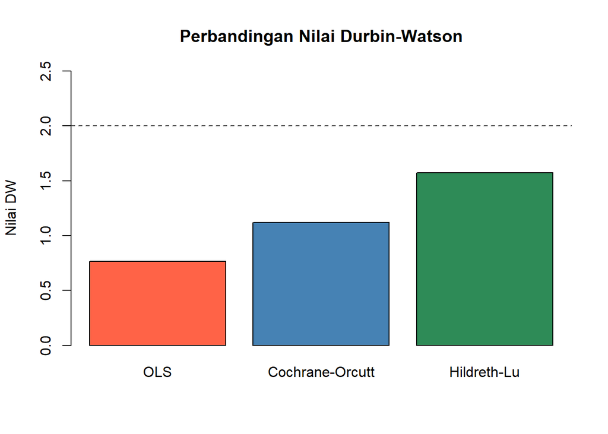

```r
barplot(perbandingan$DW_Stat, names.arg = perbandingan$Model,
        main = "Perbandingan Nilai Durbin-Watson",
        ylab = "Nilai DW", col = c("tomato", "steelblue", "seagreen"),
        ylim = c(0, 2.5))
abline(h = 2, lty = 2, col = "gray30")
```

## Kesimpulan

1. Model regresi OLS awal (IPM ~ Tahun) untuk Sulawesi Tengah sangat fit (R² = 98.14%), namun uji Durbin-Watson menunjukkan adanya autokorelasi positif pada residual (DW = 0.76, p = 0.0013).
2. Penanganan dengan Cochrane-Orcutt (ρ = 0.3959) memperbaiki DW menjadi 1.12, tetapi autokorelasi belum hilang sepenuhnya secara statistik (p = 0.0193 < 0.05).
3. Penanganan dengan Hildreth-Lu (ρ = 0.78) berhasil menaikkan DW menjadi 1.57 dengan p = 0.1224 > 0.05 - autokorelasi berhasil diatasi.
4. Untuk kasus IPM Sulawesi Tengah 2010–2021, **Hildreth-Lu terbukti lebih efektif** menghilangkan autokorelasi dibanding Cochrane-Orcutt, meskipun dengan konsekuensi R² yang lebih rendah karena transformasi data yang lebih besar.